# Risk Factor Analysis

## Outcome Variable

**Outcome Variable:** sstunted

## Predictor Variables

**Intervention Variable:** meducyrs

**Adjustment Set:**

- arm
- W_mage
- feducyrs
- hhwealth_quart
- W_mhtcm
- W_gagebrth
- W_birthwt
- W_birthlen
- W_nrooms
- impfloor
- impsan
- safeh20
- delta_W_mage
- delta_feducyrs
- delta_hhwealth_quart
- delta_W_mhtcm
- delta_W_gagebrth
- delta_W_birthwt
- delta_W_birthlen
- delta_W_nrooms
- delta_impfloor
- delta_impsan
- delta_safeh20

## Stratifying Variables

The analysis was stratified on these variable(s):

- agecat
- studyid
- country

## Data Summary

| agecat | studyid | country | meducyrs | sstunted | n_cell | n |
| --- | --- | --- | --- | --- | --- | --- |
| Birth | ki0047075b-MAL-ED | BANGLADESH | Low | 0 | 65 | 207 |
| Birth | ki0047075b-MAL-ED | BANGLADESH | Low | 1 | 3 | 207 |
| Birth | ki0047075b-MAL-ED | BANGLADESH | Medium | 0 | 62 | 207 |
| Birth | ki0047075b-MAL-ED | BANGLADESH | Medium | 1 | 2 | 207 |
| Birth | ki0047075b-MAL-ED | BANGLADESH | High | 0 | 73 | 207 |
| Birth | ki0047075b-MAL-ED | BANGLADESH | High | 1 | 2 | 207 |
| Birth | ki0047075b-MAL-ED | BRAZIL | Low | 0 | 51 | 190 |
| Birth | ki0047075b-MAL-ED | BRAZIL | Low | 1 | 1 | 190 |
| Birth | ki0047075b-MAL-ED | BRAZIL | Medium | 0 | 69 | 190 |
| Birth | ki0047075b-MAL-ED | BRAZIL | Medium | 1 | 4 | 190 |
| Birth | ki0047075b-MAL-ED | BRAZIL | High | 0 | 62 | 190 |
| Birth | ki0047075b-MAL-ED | BRAZIL | High | 1 | 3 | 190 |
| Birth | ki0047075b-MAL-ED | INDIA | Low | 0 | 60 | 183 |
| Birth | ki0047075b-MAL-ED | INDIA | Low | 1 | 1 | 183 |
| Birth | ki0047075b-MAL-ED | INDIA | Medium | 0 | 69 | 183 |
| Birth | ki0047075b-MAL-ED | INDIA | Medium | 1 | 2 | 183 |
| Birth | ki0047075b-MAL-ED | INDIA | High | 0 | 49 | 183 |
| Birth | ki0047075b-MAL-ED | INDIA | High | 1 | 2 | 183 |
| Birth | ki0047075b-MAL-ED | NEPAL | Low | 0 | 65 | 160 |
| Birth | ki0047075b-MAL-ED | NEPAL | Low | 1 | 3 | 160 |
| Birth | ki0047075b-MAL-ED | NEPAL | Medium | 0 | 52 | 160 |
| Birth | ki0047075b-MAL-ED | NEPAL | Medium | 1 | 3 | 160 |
| Birth | ki0047075b-MAL-ED | NEPAL | High | 0 | 37 | 160 |
| Birth | ki0047075b-MAL-ED | NEPAL | High | 1 | 0 | 160 |
| Birth | ki0047075b-MAL-ED | PERU | Low | 0 | 98 | 286 |
| Birth | ki0047075b-MAL-ED | PERU | Low | 1 | 1 | 286 |
| Birth | ki0047075b-MAL-ED | PERU | Medium | 0 | 97 | 286 |
| Birth | ki0047075b-MAL-ED | PERU | Medium | 1 | 3 | 286 |
| Birth | ki0047075b-MAL-ED | PERU | High | 0 | 83 | 286 |
| Birth | ki0047075b-MAL-ED | PERU | High | 1 | 4 | 286 |

[output cut: 378 more lines]

The following strata were considered:

- agecat: 24 months, studyid: ki0047075b-MAL-ED, country: BANGLADESH
- agecat: 24 months, studyid: ki0047075b-MAL-ED, country: BRAZIL
- agecat: 24 months, studyid: ki0047075b-MAL-ED, country: INDIA
- agecat: 24 months, studyid: ki0047075b-MAL-ED, country: NEPAL
- agecat: 24 months, studyid: ki0047075b-MAL-ED, country: PERU
- agecat: 24 months, studyid: ki0047075b-MAL-ED, country: SOUTH AFRICA
- agecat: 24 months, studyid: ki0047075b-MAL-ED, country: TANZANIA, UNITED REPUBLIC OF
- agecat: 24 months, studyid: ki1000108-CMC-V-BCS-2002, country: INDIA
- agecat: 24 months, studyid: ki1000108-IRC, country: INDIA
- agecat: 24 months, studyid: ki1017093-NIH-Birth, country: BANGLADESH
- agecat: 24 months, studyid: ki1017093b-PROVIDE, country: BANGLADESH
- agecat: 24 months, studyid: ki1017093c-NIH-Crypto, country: BANGLADESH
- agecat: 24 months, studyid: ki1066203-TanzaniaChild2, country: TANZANIA, UNITED REPUBLIC OF
- agecat: 24 months, studyid: ki1113344-GMS-Nepal, country: NEPAL
- agecat: 24 months, studyid: ki1119695-PROBIT, country: BELARUS
- agecat: 24 months, studyid: ki1126311-ZVITAMBO, country: ZIMBABWE
- agecat: 24 months, studyid: ki1135781-COHORTS, country: GUATEMALA
- agecat: 24 months, studyid: ki1135781-COHORTS, country: INDIA
- agecat: 24 months, studyid: ki1135781-COHORTS, country: PHILIPPINES
- agecat: 24 months, studyid: ki1148112-LCNI-5, country: MALAWI
- agecat: 24 months, studyid: kiGH5241-JiVitA-3, country: BANGLADESH
- agecat: 24 months, studyid: kiGH5241-JiVitA-4, country: BANGLADESH
- agecat: 6 months, studyid: ki0047075b-MAL-ED, country: BANGLADESH
- agecat: 6 months, studyid: ki0047075b-MAL-ED, country: BRAZIL
- agecat: 6 months, studyid: ki0047075b-MAL-ED, country: INDIA
- agecat: 6 months, studyid: ki0047075b-MAL-ED, country: NEPAL
- agecat: 6 months, studyid: ki0047075b-MAL-ED, country: PERU
- agecat: 6 months, studyid: ki0047075b-MAL-ED, country: SOUTH AFRICA
- agecat: 6 months, studyid: ki0047075b-MAL-ED, country: TANZANIA, UNITED REPUBLIC OF
- agecat: 6 months, studyid: ki1000108-CMC-V-BCS-2002, country: INDIA
- agecat: 6 months, studyid: ki1000108-IRC, country: INDIA
- agecat: 6 months, studyid: ki1000109-EE, country: PAKISTAN
- agecat: 6 months, studyid: ki1000304b-SAS-CompFeed, country: INDIA
- agecat: 6 months, studyid: ki1000304b-SAS-FoodSuppl, country: INDIA
- agecat: 6 months, studyid: ki1017093-NIH-Birth, country: BANGLADESH
- agecat: 6 months, studyid: ki1017093b-PROVIDE, country: BANGLADESH
- agecat: 6 months, studyid: ki1017093c-NIH-Crypto, country: BANGLADESH
- agecat: 6 months, studyid: ki1066203-TanzaniaChild2, country: TANZANIA, UNITED REPUBLIC OF
- agecat: 6 months, studyid: ki1112895-Guatemala BSC, country: GUATEMALA
- agecat: 6 months, studyid: ki1113344-GMS-Nepal, country: NEPAL
- agecat: 6 months, studyid: ki1119695-PROBIT, country: BELARUS
- agecat: 6 months, studyid: ki1126311-ZVITAMBO, country: ZIMBABWE
- agecat: 6 months, studyid: ki1135781-COHORTS, country: GUATEMALA
- agecat: 6 months, studyid: ki1135781-COHORTS, country: INDIA
- agecat: 6 months, studyid: ki1135781-COHORTS, country: PHILIPPINES
- agecat: 6 months, studyid: ki1148112-LCNI-5, country: MALAWI
- agecat: 6 months, studyid: kiGH5241-JiVitA-3, country: BANGLADESH
- agecat: 6 months, studyid: kiGH5241-JiVitA-4, country: BANGLADESH
- agecat: Birth, studyid: ki0047075b-MAL-ED, country: BANGLADESH
- agecat: Birth, studyid: ki0047075b-MAL-ED, country: BRAZIL
- agecat: Birth, studyid: ki0047075b-MAL-ED, country: INDIA
- agecat: Birth, studyid: ki0047075b-MAL-ED, country: NEPAL
- agecat: Birth, studyid: ki0047075b-MAL-ED, country: PERU
- agecat: Birth, studyid: ki0047075b-MAL-ED, country: SOUTH AFRICA
- agecat: Birth, studyid: ki0047075b-MAL-ED, country: TANZANIA, UNITED REPUBLIC OF
- agecat: Birth, studyid: ki1000108-CMC-V-BCS-2002, country: INDIA
- agecat: Birth, studyid: ki1000108-IRC, country: INDIA
- agecat: Birth, studyid: ki1000109-EE, country: PAKISTAN
- agecat: Birth, studyid: ki1000304b-SAS-CompFeed, country: INDIA
- agecat: Birth, studyid: ki1017093-NIH-Birth, country: BANGLADESH
- agecat: Birth, studyid: ki1017093c-NIH-Crypto, country: BANGLADESH
- agecat: Birth, studyid: ki1119695-PROBIT, country: BELARUS
- agecat: Birth, studyid: ki1126311-ZVITAMBO, country: ZIMBABWE
- agecat: Birth, studyid: ki1135781-COHORTS, country: GUATEMALA
- agecat: Birth, studyid: ki1135781-COHORTS, country: INDIA
- agecat: Birth, studyid: ki1135781-COHORTS, country: PHILIPPINES
- agecat: Birth, studyid: kiGH5241-JiVitA-3, country: BANGLADESH
- agecat: Birth, studyid: kiGH5241-JiVitA-4, country: BANGLADESH

### Dropped Strata

Some strata were dropped due to rare outcomes:

- agecat: Birth, studyid: ki0047075b-MAL-ED, country: BANGLADESH
- agecat: Birth, studyid: ki0047075b-MAL-ED, country: BRAZIL
- agecat: Birth, studyid: ki0047075b-MAL-ED, country: INDIA
- agecat: Birth, studyid: ki0047075b-MAL-ED, country: NEPAL
- agecat: Birth, studyid: ki0047075b-MAL-ED, country: PERU
- agecat: Birth, studyid: ki0047075b-MAL-ED, country: SOUTH AFRICA
- agecat: Birth, studyid: ki0047075b-MAL-ED, country: TANZANIA, UNITED REPUBLIC OF
- agecat: Birth, studyid: ki1000108-CMC-V-BCS-2002, country: INDIA
- agecat: Birth, studyid: ki1000108-IRC, country: INDIA
- agecat: Birth, studyid: ki1000109-EE, country: PAKISTAN
- agecat: Birth, studyid: ki1000304b-SAS-CompFeed, country: INDIA
- agecat: Birth, studyid: ki1017093-NIH-Birth, country: BANGLADESH
- agecat: Birth, studyid: ki1017093c-NIH-Crypto, country: BANGLADESH
- agecat: Birth, studyid: ki1119695-PROBIT, country: BELARUS
- agecat: Birth, studyid: ki1135781-COHORTS, country: GUATEMALA
- agecat: Birth, studyid: kiGH5241-JiVitA-4, country: BANGLADESH
- agecat: 6 months, studyid: ki0047075b-MAL-ED, country: BANGLADESH
- agecat: 6 months, studyid: ki0047075b-MAL-ED, country: BRAZIL
- agecat: 6 months, studyid: ki0047075b-MAL-ED, country: INDIA
- agecat: 6 months, studyid: ki0047075b-MAL-ED, country: NEPAL
- agecat: 6 months, studyid: ki0047075b-MAL-ED, country: PERU
- agecat: 6 months, studyid: ki0047075b-MAL-ED, country: SOUTH AFRICA
- agecat: 6 months, studyid: ki0047075b-MAL-ED, country: TANZANIA, UNITED REPUBLIC OF
- agecat: 6 months, studyid: ki1000109-EE, country: PAKISTAN
- agecat: 6 months, studyid: ki1000304b-SAS-FoodSuppl, country: INDIA
- agecat: 6 months, studyid: ki1017093-NIH-Birth, country: BANGLADESH
- agecat: 6 months, studyid: ki1017093b-PROVIDE, country: BANGLADESH
- agecat: 6 months, studyid: ki1066203-TanzaniaChild2, country: TANZANIA, UNITED REPUBLIC OF
- agecat: 6 months, studyid: ki1113344-GMS-Nepal, country: NEPAL
- agecat: 24 months, studyid: ki0047075b-MAL-ED, country: BANGLADESH
- agecat: 24 months, studyid: ki0047075b-MAL-ED, country: BRAZIL
- agecat: 24 months, studyid: ki0047075b-MAL-ED, country: INDIA
- agecat: 24 months, studyid: ki0047075b-MAL-ED, country: NEPAL
- agecat: 24 months, studyid: ki0047075b-MAL-ED, country: PERU
- agecat: 24 months, studyid: ki0047075b-MAL-ED, country: SOUTH AFRICA
- agecat: 24 months, studyid: ki0047075b-MAL-ED, country: TANZANIA, UNITED REPUBLIC OF
- agecat: 24 months, studyid: ki1066203-TanzaniaChild2, country: TANZANIA, UNITED REPUBLIC OF
- agecat: 24 months, studyid: ki1113344-GMS-Nepal, country: NEPAL
- agecat: 24 months, studyid: ki1119695-PROBIT, country: BELARUS

## Methods Detail

We’re interested in the causal parameters $E[Y_a]$ for all values of $a \in \mathcal{A}$. These parameters represent the mean outcome if, possibly contrary to fact, we intervened to set all units to have $A=a$. Under the randomization and positivity assumptions, these are identified by the statistical parameters $\psi_a=E_W[E_{Y|A,W}(Y|A=a,W)]$. In addition, we’re interested in the mean of $Y$, $E[Y]$ under no intervention (the observed mean). We will estimate these parameters by using SuperLearner to fit the relevant likelihood factors – $E_{Y|A,W}(Y|A=a,W)$ and $p(A=a|W)$, and then updating our likelihood fit using a joint TMLE.

For unadjusted analyses ($W=\{\}$), initial likelihoods were estimated using Lrnr_glm to estimate the simple $E(Y|A)$ and Lrnr_mean to estimate $p(A)$. For adjusted analyses, a small library containing Lrnr_glmnet, Lrnr_xgboost, and Lrnr_mean was used.

Having estimated these parameters, we will then use the delta method to estimate relative risks and attributable risks relative to a prespecified baseline level of $A$.

# Results Detail

## Results Plots

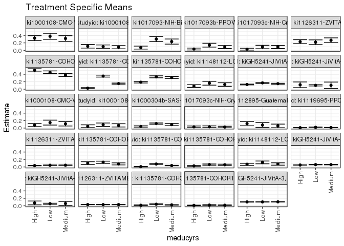

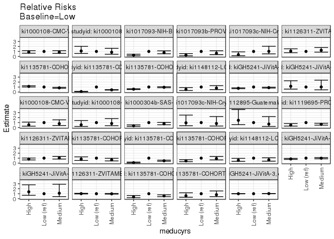

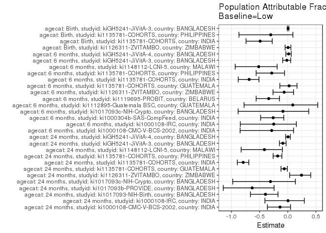

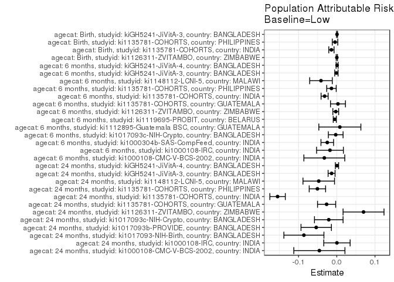

## Results Table

### Parameter: TSM

| agecat | studyid | country | intervention_level | baseline_level | estimate | ci_lower | ci_upper |
| --- | --- | --- | --- | --- | --- | --- | --- |
| Birth | ki1126311-ZVITAMBO | ZIMBABWE | Low | NA | 0.0317698 | 0.0284444 | 0.0350952 |
| Birth | ki1126311-ZVITAMBO | ZIMBABWE | Medium | NA | 0.0310496 | 0.0278743 | 0.0342249 |
| Birth | ki1126311-ZVITAMBO | ZIMBABWE | High | NA | 0.0320731 | 0.0290780 | 0.0350683 |
| Birth | ki1135781-COHORTS | INDIA | Low | NA | 0.0425853 | 0.0334093 | 0.0517613 |
| Birth | ki1135781-COHORTS | INDIA | Medium | NA | 0.0239329 | 0.0182845 | 0.0295812 |
| Birth | ki1135781-COHORTS | INDIA | High | NA | 0.0149319 | 0.0065308 | 0.0233331 |
| Birth | ki1135781-COHORTS | PHILIPPINES | Low | NA | 0.0196510 | 0.0106818 | 0.0286202 |
| Birth | ki1135781-COHORTS | PHILIPPINES | Medium | NA | 0.0156328 | 0.0079448 | 0.0233207 |
| Birth | ki1135781-COHORTS | PHILIPPINES | High | NA | 0.0115498 | 0.0053408 | 0.0177588 |
| Birth | kiGH5241-JiVitA-3 | BANGLADESH | Low | NA | 0.1035649 | 0.0988472 | 0.1082826 |
| Birth | kiGH5241-JiVitA-3 | BANGLADESH | Medium | NA | 0.1059748 | 0.1008155 | 0.1111341 |
| Birth | kiGH5241-JiVitA-3 | BANGLADESH | High | NA | 0.1030376 | 0.0980914 | 0.1079839 |
| 6 months | ki1000108-CMC-V-BCS-2002 | INDIA | Low | NA | 0.1464005 | 0.0801415 | 0.2126595 |
| 6 months | ki1000108-CMC-V-BCS-2002 | INDIA | Medium | NA | 0.1145747 | 0.0552066 | 0.1739427 |
| 6 months | ki1000108-CMC-V-BCS-2002 | INDIA | High | NA | 0.0800294 | 0.0377723 | 0.1222866 |
| 6 months | ki1000108-IRC | INDIA | Low | NA | 0.0890411 | 0.0427870 | 0.1352952 |
| 6 months | ki1000108-IRC | INDIA | Medium | NA | 0.0724638 | 0.0291557 | 0.1157718 |
| 6 months | ki1000108-IRC | INDIA | High | NA | 0.0487805 | 0.0106657 | 0.0868952 |
| 6 months | ki1000304b-SAS-CompFeed | INDIA | Low | NA | 0.1206639 | 0.1044872 | 0.1368407 |
| 6 months | ki1000304b-SAS-CompFeed | INDIA | Medium | NA | 0.0923927 | 0.0629733 | 0.1218121 |
| 6 months | ki1000304b-SAS-CompFeed | INDIA | High | NA | 0.0426531 | 0.0249496 | 0.0603566 |
| 6 months | ki1017093c-NIH-Crypto | BANGLADESH | Low | NA | 0.0349345 | 0.0111365 | 0.0587325 |
| 6 months | ki1017093c-NIH-Crypto | BANGLADESH | Medium | NA | 0.0284553 | 0.0076632 | 0.0492473 |
| 6 months | ki1017093c-NIH-Crypto | BANGLADESH | High | NA | 0.0333333 | 0.0106073 | 0.0560594 |
| 6 months | ki1112895-Guatemala BSC | GUATEMALA | Low | NA | 0.0821918 | 0.0190725 | 0.1453111 |
| 6 months | ki1112895-Guatemala BSC | GUATEMALA | Medium | NA | 0.0574713 | 0.0084769 | 0.1064657 |
| 6 months | ki1112895-Guatemala BSC | GUATEMALA | High | NA | 0.1196581 | 0.0607416 | 0.1785747 |
| 6 months | ki1119695-PROBIT | BELARUS | Low | NA | 0.0206376 | 0.0121155 | 0.0291596 |
| 6 months | ki1119695-PROBIT | BELARUS | Medium | NA | 0.0132976 | 0.0081477 | 0.0184475 |
| 6 months | ki1119695-PROBIT | BELARUS | High | NA | 0.0098753 | 0.0062638 | 0.0134869 |

[output cut: 57 more lines]

### Parameter: E(Y)

| agecat | studyid | country | intervention_level | baseline_level | estimate | ci_lower | ci_upper |
| --- | --- | --- | --- | --- | --- | --- | --- |
| Birth | ki1126311-ZVITAMBO | ZIMBABWE | NA | NA | 0.0319334 | 0.0290009 | 0.0348659 |
| Birth | ki1135781-COHORTS | INDIA | NA | NA | 0.0285660 | 0.0240448 | 0.0330871 |
| Birth | ki1135781-COHORTS | PHILIPPINES | NA | NA | 0.0150820 | 0.0107558 | 0.0194081 |
| Birth | kiGH5241-JiVitA-3 | BANGLADESH | NA | NA | 0.1042018 | 0.0995258 | 0.1088777 |
| 6 months | ki1000108-CMC-V-BCS-2002 | INDIA | NA | NA | 0.1138211 | 0.0813725 | 0.1462698 |
| 6 months | ki1000108-IRC | INDIA | NA | NA | 0.0712531 | 0.0462303 | 0.0962759 |
| 6 months | ki1000304b-SAS-CompFeed | INDIA | NA | NA | 0.0958084 | 0.0774939 | 0.1141229 |
| 6 months | ki1017093c-NIH-Crypto | BANGLADESH | NA | NA | 0.0321678 | 0.0192256 | 0.0451101 |
| 6 months | ki1112895-Guatemala BSC | GUATEMALA | NA | NA | 0.0902527 | 0.0564475 | 0.1240580 |
| 6 months | ki1119695-PROBIT | BELARUS | NA | NA | 0.0154178 | 0.0100323 | 0.0208033 |
| 6 months | ki1126311-ZVITAMBO | ZIMBABWE | NA | NA | 0.0417773 | 0.0374680 | 0.0460867 |
| 6 months | ki1135781-COHORTS | GUATEMALA | NA | NA | 0.1281513 | 0.1069071 | 0.1493954 |
| 6 months | ki1135781-COHORTS | INDIA | NA | NA | 0.0463699 | 0.0407674 | 0.0519723 |
| 6 months | ki1135781-COHORTS | PHILIPPINES | NA | NA | 0.0487445 | 0.0406327 | 0.0568562 |
| 6 months | ki1148112-LCNI-5 | MALAWI | NA | NA | 0.0799508 | 0.0612962 | 0.0986054 |
| 6 months | kiGH5241-JiVitA-3 | BANGLADESH | NA | NA | 0.0606684 | 0.0568070 | 0.0645298 |
| 6 months | kiGH5241-JiVitA-4 | BANGLADESH | NA | NA | 0.0561826 | 0.0434820 | 0.0688832 |
| 24 months | ki1000108-CMC-V-BCS-2002 | INDIA | NA | NA | 0.3306452 | 0.2827744 | 0.3785159 |
| 24 months | ki1000108-IRC | INDIA | NA | NA | 0.1002445 | 0.0711031 | 0.1293859 |
| 24 months | ki1017093-NIH-Birth | BANGLADESH | NA | NA | 0.2167832 | 0.1777459 | 0.2558205 |
| 24 months | ki1017093b-PROVIDE | BANGLADESH | NA | NA | 0.0849220 | 0.0621566 | 0.1076874 |
| 24 months | ki1017093c-NIH-Crypto | BANGLADESH | NA | NA | 0.0680934 | 0.0462948 | 0.0898920 |
| 24 months | ki1126311-ZVITAMBO | ZIMBABWE | NA | NA | 0.2866521 | 0.2451477 | 0.3281565 |
| 24 months | ki1135781-COHORTS | GUATEMALA | NA | NA | 0.4273585 | 0.3975639 | 0.4571531 |
| 24 months | ki1135781-COHORTS | INDIA | NA | NA | 0.1954297 | 0.1834374 | 0.2074219 |
| 24 months | ki1135781-COHORTS | PHILIPPINES | NA | NA | 0.2817996 | 0.2639639 | 0.2996353 |
| 24 months | ki1148112-LCNI-5 | MALAWI | NA | NA | 0.1136364 | 0.0876051 | 0.1396676 |
| 24 months | kiGH5241-JiVitA-3 | BANGLADESH | NA | NA | 0.1556615 | 0.1469265 | 0.1643965 |
| 24 months | kiGH5241-JiVitA-4 | BANGLADESH | NA | NA | 0.1030612 | 0.0873670 | 0.1187554 |

### Parameter: RR

| agecat | studyid | country | intervention_level | baseline_level | estimate | ci_lower | ci_upper |
| --- | --- | --- | --- | --- | --- | --- | --- |
| Birth | ki1126311-ZVITAMBO | ZIMBABWE | Low | Low | 1.0000000 | 1.0000000 | 1.0000000 |
| Birth | ki1126311-ZVITAMBO | ZIMBABWE | Medium | Low | 0.9773311 | 0.9052069 | 1.0552020 |
| Birth | ki1126311-ZVITAMBO | ZIMBABWE | High | Low | 1.0095487 | 0.9454674 | 1.0779733 |
| Birth | ki1135781-COHORTS | INDIA | Low | Low | 1.0000000 | 1.0000000 | 1.0000000 |
| Birth | ki1135781-COHORTS | INDIA | Medium | Low | 0.5619983 | 0.4083264 | 0.7735039 |
| Birth | ki1135781-COHORTS | INDIA | High | Low | 0.3506359 | 0.1919385 | 0.6405465 |
| Birth | ki1135781-COHORTS | PHILIPPINES | Low | Low | 1.0000000 | 1.0000000 | 1.0000000 |
| Birth | ki1135781-COHORTS | PHILIPPINES | Medium | Low | 0.7955188 | 0.4068576 | 1.5554586 |
| Birth | ki1135781-COHORTS | PHILIPPINES | High | Low | 0.5877435 | 0.2905153 | 1.1890680 |
| Birth | kiGH5241-JiVitA-3 | BANGLADESH | Low | Low | 1.0000000 | 1.0000000 | 1.0000000 |
| Birth | kiGH5241-JiVitA-3 | BANGLADESH | Medium | Low | 1.0232690 | 0.9984930 | 1.0486598 |
| Birth | kiGH5241-JiVitA-3 | BANGLADESH | High | Low | 0.9949085 | 0.9684791 | 1.0220591 |
| 6 months | ki1000108-CMC-V-BCS-2002 | INDIA | Low | Low | 1.0000000 | 1.0000000 | 1.0000000 |
| 6 months | ki1000108-CMC-V-BCS-2002 | INDIA | Medium | Low | 0.7826111 | 0.3934125 | 1.5568398 |
| 6 months | ki1000108-CMC-V-BCS-2002 | INDIA | High | Low | 0.5466473 | 0.2725199 | 1.0965191 |
| 6 months | ki1000108-IRC | INDIA | Low | Low | 1.0000000 | 1.0000000 | 1.0000000 |
| 6 months | ki1000108-IRC | INDIA | Medium | Low | 0.8138239 | 0.3686650 | 1.7965071 |
| 6 months | ki1000108-IRC | INDIA | High | Low | 0.5478424 | 0.2143719 | 1.4000494 |
| 6 months | ki1000304b-SAS-CompFeed | INDIA | Low | Low | 1.0000000 | 1.0000000 | 1.0000000 |
| 6 months | ki1000304b-SAS-CompFeed | INDIA | Medium | Low | 0.7657025 | 0.5628584 | 1.0416479 |
| 6 months | ki1000304b-SAS-CompFeed | INDIA | High | Low | 0.3534869 | 0.2328965 | 0.5365174 |
| 6 months | ki1017093c-NIH-Crypto | BANGLADESH | Low | Low | 1.0000000 | 1.0000000 | 1.0000000 |
| 6 months | ki1017093c-NIH-Crypto | BANGLADESH | Medium | Low | 0.8145325 | 0.2999546 | 2.2118786 |
| 6 months | ki1017093c-NIH-Crypto | BANGLADESH | High | Low | 0.9541667 | 0.3639632 | 2.5014455 |
| 6 months | ki1112895-Guatemala BSC | GUATEMALA | Low | Low | 1.0000000 | 1.0000000 | 1.0000000 |
| 6 months | ki1112895-Guatemala BSC | GUATEMALA | Medium | Low | 0.6992337 | 0.2219811 | 2.2025649 |
| 6 months | ki1112895-Guatemala BSC | GUATEMALA | High | Low | 1.4558405 | 0.5846999 | 3.6248875 |
| 6 months | ki1119695-PROBIT | BELARUS | Low | Low | 1.0000000 | 1.0000000 | 1.0000000 |
| 6 months | ki1119695-PROBIT | BELARUS | Medium | Low | 0.6443399 | 0.4820511 | 0.8612653 |
| 6 months | ki1119695-PROBIT | BELARUS | High | Low | 0.4785133 | 0.2855160 | 0.8019690 |

[output cut: 57 more lines]

### Parameter: PAR

| agecat | studyid | country | intervention_level | baseline_level | estimate | ci_lower | ci_upper |
| --- | --- | --- | --- | --- | --- | --- | --- |
| Birth | ki1126311-ZVITAMBO | ZIMBABWE | Low | NA | 0.0001636 | -0.0014791 | 0.0018063 |
| Birth | ki1135781-COHORTS | INDIA | Low | NA | -0.0140194 | -0.0208882 | -0.0071505 |
| Birth | ki1135781-COHORTS | PHILIPPINES | Low | NA | -0.0045691 | -0.0117498 | 0.0026117 |
| Birth | kiGH5241-JiVitA-3 | BANGLADESH | Low | NA | 0.0006368 | -0.0007328 | 0.0020064 |
| 6 months | ki1000108-CMC-V-BCS-2002 | INDIA | Low | NA | -0.0325794 | -0.0860709 | 0.0209122 |
| 6 months | ki1000108-IRC | INDIA | Low | NA | -0.0177880 | -0.0528687 | 0.0172926 |
| 6 months | ki1000304b-SAS-CompFeed | INDIA | Low | NA | -0.0248556 | -0.0413521 | -0.0083590 |
| 6 months | ki1017093c-NIH-Crypto | BANGLADESH | Low | NA | -0.0027667 | -0.0220298 | 0.0164965 |
| 6 months | ki1112895-Guatemala BSC | GUATEMALA | Low | NA | 0.0080609 | -0.0469568 | 0.0630786 |
| 6 months | ki1119695-PROBIT | BELARUS | Low | NA | -0.0052198 | -0.0092414 | -0.0011981 |
| 6 months | ki1126311-ZVITAMBO | ZIMBABWE | Low | NA | -0.0026800 | -0.0102700 | 0.0049099 |
| 6 months | ki1135781-COHORTS | GUATEMALA | Low | NA | 0.0031197 | -0.0164412 | 0.0226806 |
| 6 months | ki1135781-COHORTS | INDIA | Low | NA | -0.0318519 | -0.0410675 | -0.0226362 |
| 6 months | ki1135781-COHORTS | PHILIPPINES | Low | NA | -0.0139052 | -0.0262989 | -0.0015116 |
| 6 months | ki1148112-LCNI-5 | MALAWI | Low | NA | -0.0412991 | -0.0708498 | -0.0117483 |
| 6 months | kiGH5241-JiVitA-3 | BANGLADESH | Low | NA | -0.0009694 | -0.0053101 | 0.0033712 |
| 6 months | kiGH5241-JiVitA-4 | BANGLADESH | Low | NA | 0.0008657 | -0.0017851 | 0.0035165 |
| 24 months | ki1000108-CMC-V-BCS-2002 | INDIA | Low | NA | -0.0455375 | -0.1124629 | 0.0213879 |
| 24 months | ki1000108-IRC | INDIA | Low | NA | 0.0004531 | -0.0340363 | 0.0349425 |
| 24 months | ki1017093-NIH-Birth | BANGLADESH | Low | NA | -0.0860324 | -0.1384386 | -0.0336262 |
| 24 months | ki1017093b-PROVIDE | BANGLADESH | Low | NA | -0.0538063 | -0.0935841 | -0.0140285 |
| 24 months | ki1017093c-NIH-Crypto | BANGLADESH | Low | NA | -0.0209477 | -0.0583475 | 0.0164521 |
| 24 months | ki1126311-ZVITAMBO | ZIMBABWE | Low | NA | 0.0700081 | 0.0164275 | 0.1235887 |
| 24 months | ki1135781-COHORTS | GUATEMALA | Low | NA | -0.0265943 | -0.0503338 | -0.0028548 |
| 24 months | ki1135781-COHORTS | INDIA | Low | NA | -0.1548700 | -0.1750810 | -0.1346589 |
| 24 months | ki1135781-COHORTS | PHILIPPINES | Low | NA | -0.0506613 | -0.0721157 | -0.0292070 |
| 24 months | ki1148112-LCNI-5 | MALAWI | Low | NA | -0.0471733 | -0.0884610 | -0.0058856 |
| 24 months | kiGH5241-JiVitA-3 | BANGLADESH | Low | NA | -0.0135676 | -0.0226871 | -0.0044480 |
| 24 months | kiGH5241-JiVitA-4 | BANGLADESH | Low | NA | 0.0005628 | -0.0036978 | 0.0048235 |

### Parameter: PAF

| agecat | studyid | country | intervention_level | baseline_level | estimate | ci_lower | ci_upper |
| --- | --- | --- | --- | --- | --- | --- | --- |
| Birth | ki1126311-ZVITAMBO | ZIMBABWE | Low | NA | 0.0051232 | -0.0476607 | 0.0552478 |
| Birth | ki1135781-COHORTS | INDIA | Low | NA | -0.4907714 | -0.7419452 | -0.2758147 |
| Birth | ki1135781-COHORTS | PHILIPPINES | Low | NA | -0.3029481 | -0.8685902 | 0.0914681 |
| Birth | kiGH5241-JiVitA-3 | BANGLADESH | Low | NA | 0.0061115 | -0.0070902 | 0.0191401 |
| 6 months | ki1000108-CMC-V-BCS-2002 | INDIA | Low | NA | -0.2862329 | -0.8476067 | 0.1045740 |
| 6 months | ki1000108-IRC | INDIA | Low | NA | -0.2496457 | -0.8436755 | 0.1529884 |
| 6 months | ki1000304b-SAS-CompFeed | INDIA | Low | NA | -0.2594298 | -0.4816446 | -0.0705425 |
| 6 months | ki1017093c-NIH-Crypto | BANGLADESH | Low | NA | -0.0860072 | -0.8833659 | 0.3737745 |
| 6 months | ki1112895-Guatemala BSC | GUATEMALA | Low | NA | 0.0893151 | -0.7771256 | 0.5333211 |
| 6 months | ki1119695-PROBIT | BELARUS | Low | NA | -0.3385538 | -0.5626520 | -0.1465932 |
| 6 months | ki1126311-ZVITAMBO | ZIMBABWE | Low | NA | -0.0641504 | -0.2627834 | 0.1032381 |
| 6 months | ki1135781-COHORTS | GUATEMALA | Low | NA | 0.0243438 | -0.1408760 | 0.1656367 |
| 6 months | ki1135781-COHORTS | INDIA | Low | NA | -0.6869091 | -0.8809689 | -0.5128705 |
| 6 months | ki1135781-COHORTS | PHILIPPINES | Low | NA | -0.2852679 | -0.5625566 | -0.0571864 |
| 6 months | ki1148112-LCNI-5 | MALAWI | Low | NA | -0.5165559 | -0.9353539 | -0.1883830 |
| 6 months | kiGH5241-JiVitA-3 | BANGLADESH | Low | NA | -0.0159788 | -0.0901470 | 0.0531433 |
| 6 months | kiGH5241-JiVitA-4 | BANGLADESH | Low | NA | 0.0154092 | -0.0335293 | 0.0620305 |
| 24 months | ki1000108-CMC-V-BCS-2002 | INDIA | Low | NA | -0.1377232 | -0.3620246 | 0.0496397 |
| 24 months | ki1000108-IRC | INDIA | Low | NA | 0.0045200 | -0.4064086 | 0.2953822 |
| 24 months | ki1017093-NIH-Birth | BANGLADESH | Low | NA | -0.3968591 | -0.6630929 | -0.1732450 |
| 24 months | ki1017093b-PROVIDE | BANGLADESH | Low | NA | -0.6335968 | -1.1469856 | -0.2429699 |
| 24 months | ki1017093c-NIH-Crypto | BANGLADESH | Low | NA | -0.3076321 | -0.9793108 | 0.1361126 |
| 24 months | ki1126311-ZVITAMBO | ZIMBABWE | Low | NA | 0.2442267 | 0.0337926 | 0.4088296 |
| 24 months | ki1135781-COHORTS | GUATEMALA | Low | NA | -0.0622294 | -0.1199872 | -0.0074502 |
| 24 months | ki1135781-COHORTS | INDIA | Low | NA | -0.7924588 | -0.8975046 | -0.6932284 |
| 24 months | ki1135781-COHORTS | PHILIPPINES | Low | NA | -0.1797779 | -0.2602180 | -0.1044723 |
| 24 months | ki1148112-LCNI-5 | MALAWI | Low | NA | -0.4151250 | -0.8290521 | -0.0948724 |
| 24 months | kiGH5241-JiVitA-3 | BANGLADESH | Low | NA | -0.0871607 | -0.1478290 | -0.0296991 |
| 24 months | kiGH5241-JiVitA-4 | BANGLADESH | Low | NA | 0.0054612 | -0.0367456 | 0.0459497 |